# Random Number Generation and Sampling

CHEN YONG, yongc2

September 22, 2018

## Exercise 1

**R Syntax and class-typing.**

**(a)** For each of the following commands, either explain why they should be errors, or explain the non-erroneous result.

```
vector1 <- c("3", "3", "8", "2", "4")
vector1*2
sort(vector1)
sum(vector1)
```

1.non-error. Because the numbers are quoted as characters, vector1 is a character vector.  
2.error. Characters cannot time a scaler.  
3.non-error. The function sort can be used to sort vectors in order.  
4.error. You cannot numeric calculation with characters, “a”+“b” cannot be “ab”.  
**(b)** For the next series of commands, either explain their results, or why they should produce errors.

```
vector2 <- c("5",7,12)
vector2[2] + vector2[3]

dataframe3 <- data.frame(z1=5,z2="cat",z3=1)
dataframe3[1,1] + dataframe3[1,3]

list4 <- list(z1="100", z2=25, z3="98", z4=126)
list4[[1]]+list4[[2]]
list4[[2]]+list4[[4]]
list4[2]+list4[4]
list4[2]$z2 + list4[4]$z4
```

1.error. Because “5” is a character, R will take the vector as character type and input others as characters.  
2.error. The type of vector2 is character, so the elements in vector2 are all characters so they arenot addable.  
3.non-error. You can have diffierent object types in diffirent elements in a dataframe.  
4.non-error. The first and thrid element of dataframe3 are scaler, they are addable.  
5.non-error. Each element in a list is like a drawer, you can put diffirent things into each one.  
6.error. list4[[1]] is a character and list4[[2]] is a number.  
7.non-error. List4[[2]] and list4[[4]] are both scalers, they can be addable.  
8.error. There are two elements in each list4[i],i=1??4 and they are not all scalers.  
9.non-error. “list4[2]$z2”" stands for the value of the second element of list4 which is a scaler. Same for “list4[4] z4”.

## Exercise 2

**Working with functions and operators.**

**(a)** The colon operator will create a sequence of integers in order. It is a special case of the function `seq()`. Using the help command `?seq` to learn about the function, design an expression that will give you the sequence of numbers from 1 to 10000 in increments of 203. Design another that will give you a sequence between 1 and 10000 that is exactly 18 numbers in length.

```r
seq(1,10000,203)
```

```
##  [1]    1  204  407  610  813 1016 1219 1422 1625 1828 2031 2234 2437 2640 2843
## [16] 3046 3249 3452 3655 3858 4061 4264 4467 4670 4873 5076 5279 5482 5685 5888
## [31] 6091 6294 6497 6700 6903 7106 7309 7512 7715 7918 8121 8324 8527 8730 8933
## [46] 9136 9339 9542 9745 9948
```

```r
seq(1,10000,length.out=18)
```

```
##  [1]     1.0   589.2  1177.4  1765.5  2353.7  2941.9  3530.1  4118.2  4706.4
## [10]  5294.6  5882.8  6470.9  7059.1  7647.3  8235.5  8823.6  9411.8 10000.0
```

**(b)** The function `rep()` repeats a vector some number of times. Explain the difference between `rep(1:4, times=4)` and `rep(1:4, each=4)`.  
`rep(1:4, times=4)` means that from 1 to 4, take the whole sequence as a unit and repeat it for 4 times. `rep(1:4, each=4)` means that it takes each number as a unit and repeat each of them for 4 times.

## Exercise 3

Writing R functions. Write an `R` function that accepts a vector as an argument and returns the standard deviation of that vector. You may not use the pre-existing functions sd(), var(), or anything similar.

```r
standrad_deviation=function(vec){
  a=matrix(0,length(vec),1)
  for (i in 1:length(vec)){
    a[i]=(vec[i]-mean(vec))^2
  }
  sd=sqrt(sum(a)/(length(vec)-1))
  return(sd)
}
```

## Exercise 4

- **(a)** Write a program that simulates 10,000 Beta(2,4) random variables using both methods. Method1:

```r
n=10000
k=0
j=0
M=0.1055
y=numeric(n)
while(k<n){
  u=runif(1)
  j=j+1
  x=runif(1)
  if((x*(1-x)^3)/(M*1)>u){
    k=k+1
    y[k]=x
  }
}
```

Method2:

```r
n=10000
k=0
j=0
M=0.2499
y2=numeric(n)
while(k<n){
  u=runif(1)
  j=j+1
  x=mean(runif(2))
  if((x*(1-x)^3)/(M*(2-abs(4*x-2)))>u){
    k=k+1
    y2[k]=x
  }
}
```

- **(b)** Compare the acceptance rates and decide which one is the better algorithm.  
  Method1

```r
Y=runif(n)
for (i in 1:n){
  Y[i]=Y[i]*(runif(1)<(Y[i]*(1-Y[i]^3)/M))
}
Y=Y[Y!=0]
length(Y)/n
```

```
## [1] 0.8236
```

Method2

```r
Y2=runif(n)
for (i in 1:n){
  Y2[i]=Y2[i]*(runif(1)<(Y2[i]*(1-Y2[i]^3)/M*(2-abs(4*Y2[i]-2))))
}
Y2=Y2[Y2!=0]
length(Y2)/n
```

```
## [1] 0.7279
```

Compared the acceptence rate of two methods, we know they method 1 is better.  
- **(c)** Is it correct to use theoretical acceptance rate $\frac{1}{M}$. Why or why not?  
Not correct, because here we know that M is less than 1, so 1/M will be larger than 1.

```r
1/M
```

```
## [1] 4.002
```

- **(c)** Graph histograms of your results.

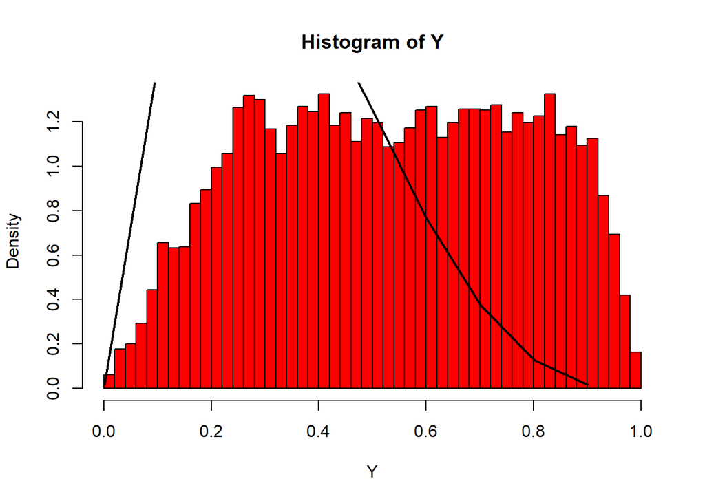

```r
hist(Y,freq=F,col="red",breaks=50)
yplot=seq(min(Y),max(Y),.1)
lines(yplot,dbeta(yplot,2,4),lwd=2)
```

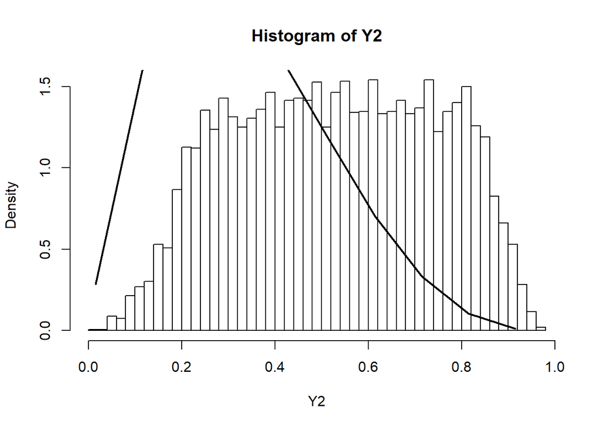

```r
hist(Y2,freq=F,breaks=50)
yplot1=seq(min(Y2),max(Y2),.1)
lines(yplot1,dbeta(yplot1,2,4),lwd=2)
```

- **(d)** Summarizes your findings. Keep the g(x) as simple as possible, if M is less than 1, than the theorical accceptance rate is not correct. ## Exercise 5
- **(a)** Simulate 10000 pairs of random variables $(X_1, X_2)$, both from $Unif(-1,1)$.

```r
s=10000
x1=runif(s,-1,1)
x2=runif(s,-1,1)
```

- **(b)** Find the number of times that $(X_1^2 + X_2^2) \leq 1$ for your sample. Call this number `n`.

```r
ab=s*((x1^2+x2^2)<=1)
ab=ab[ab!=0]
n=length(ab)
n
```

```
## [1] 7811
```

- **(c)** Estimate $\pi$ by the number $4n/10000$. Check how close it is to the value given by `pi` in `R`.

```r
pi_h=4*n/10000
pi-pi_h
```

```
## [1] 0.01719
```

- **(d)** Repeat this process 100 times to get a vector of estimates $\tilde{\pi}$.

```r
pi_h=matrix(0,100,1)
for (i in 1:100){
  s=10000
  x1=runif(s,-1,1)
  x2=runif(s,-1,1)
  ab=s*(x1^2+x2^2<1)
  ab=ab[ab!=0]
  n=length(ab)
  pi_h[i]= 4*n/10000
}
```

- **(e)** Estimate the error in our approximation by calculating standard deviation of the vector $\tilde{\pi}$ divided by 10.

```r
sd(pi_h)/10
```

```
## [1] 0.0016
```

## Exercise 6

Derive the probability inverse transformation $F^{-1}(U)$ and use the inverse transform method to simulate 1000 random samples from this distribution. Graph the density histogram of the sample.

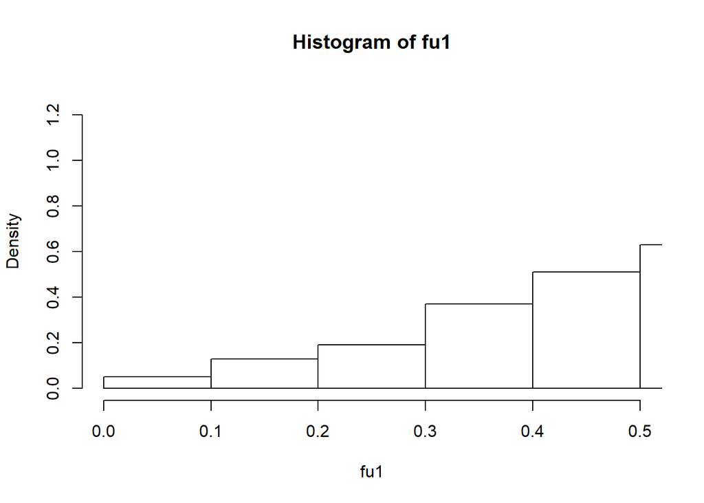

```r
n=1000
u=runif(n)
fu1=sqrt(2*u)
fu2=sqrt(4-2*u)+2
hist(fu1,prob=TRUE,xlim=c(0,0.5))
```

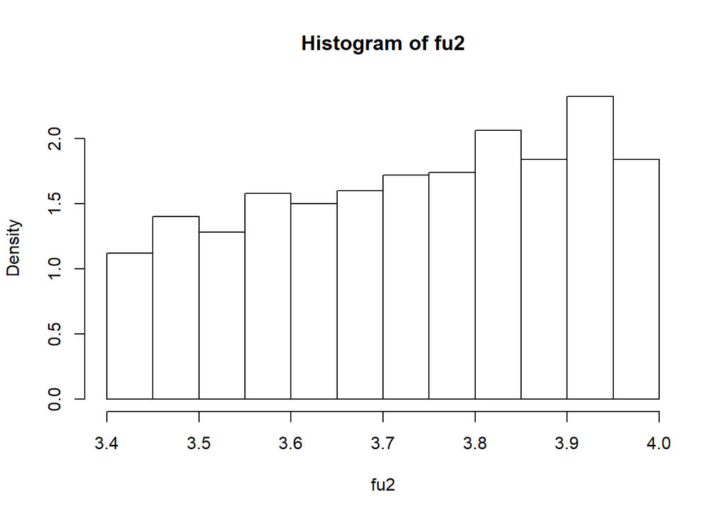

```r
hist(fu2,prob=TRUE)
```

## Exercise 7

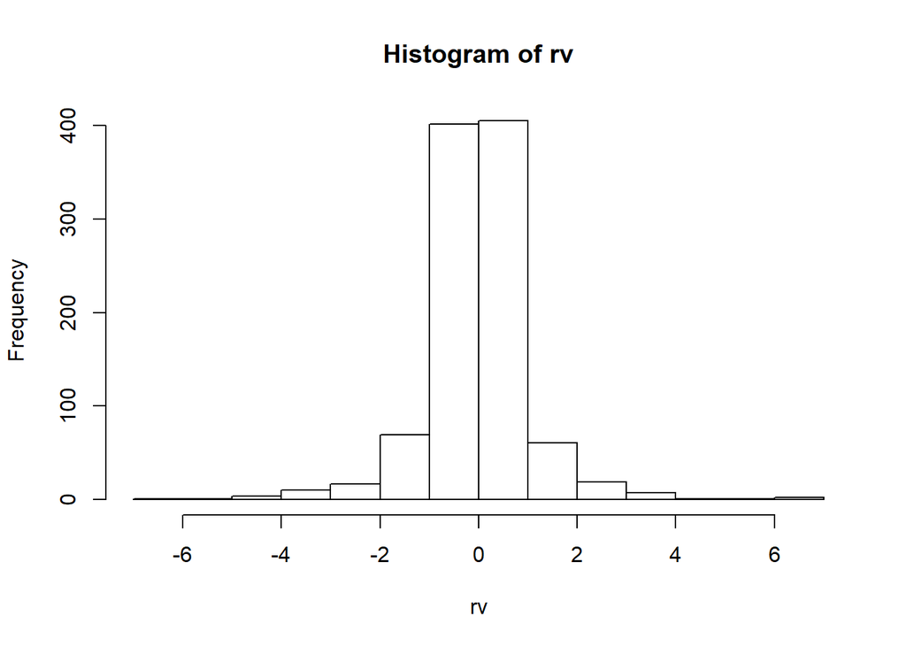

```r
u=runif(1000,-1,1)
rv=numeric(1000)
for (i in 1:1000){
  rv[i]=ifelse(u[i]<0,-log(-2*u[i]),log(2*u[i]))
}
hist(rv)
```

## Exercise 8

```r
n=1000
u=runif(n)
x=sqrt(4/1-u)
x[1]
```

```
## [1] 1.786
```

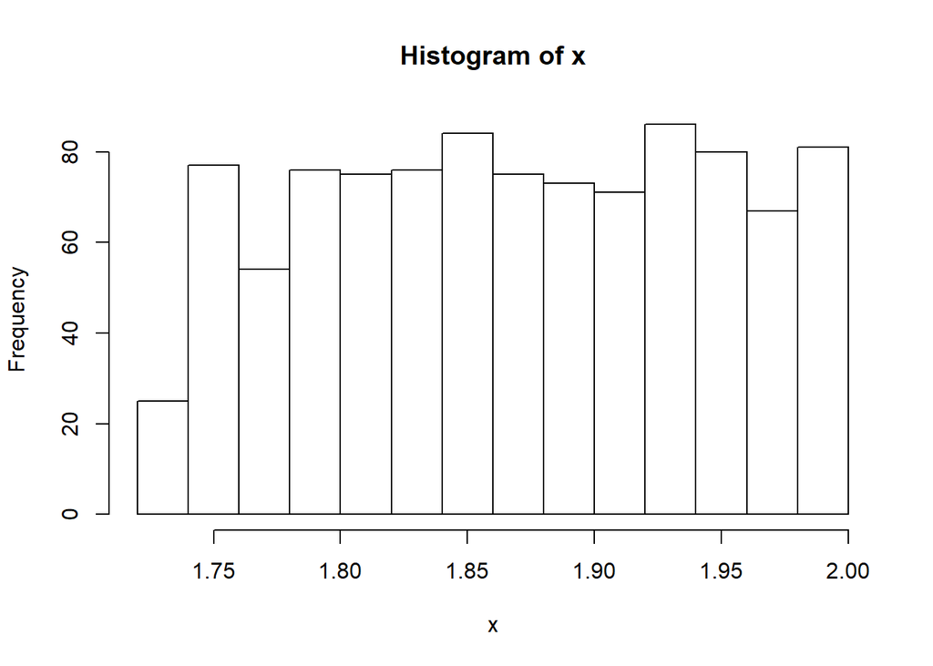

```r
hist(x)
```

## Exercise 9

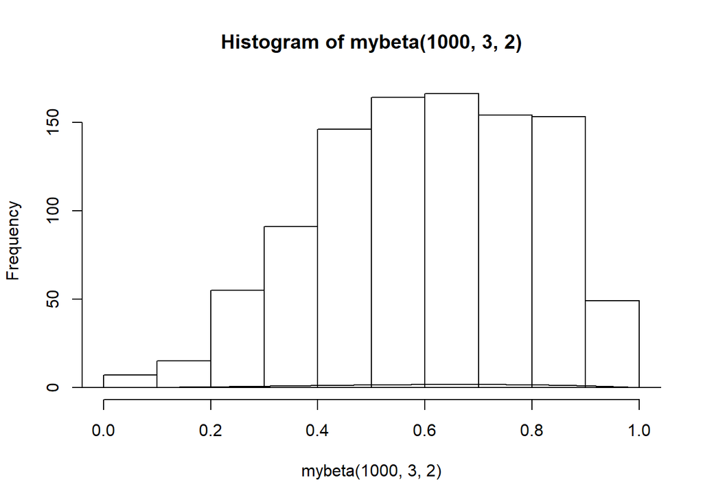

```r
n=1000
mybeta=function(n,a,b){
  u=rgamma(n,shape = a,rate=1)
  v=rgamma(n,shape = b,rate=1)
  x=u/(u+v)
  return(x)
}
hist(mybeta(1000,3,2))
x=seq(-2,2,length.out = 1000)
lines(x,dbeta(x,3,2))
```

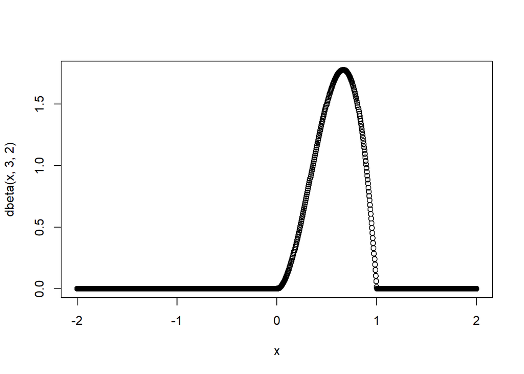

```r
plot(x,dbeta(x,3,2))
```

## Exercise 10 generate 1000 rv

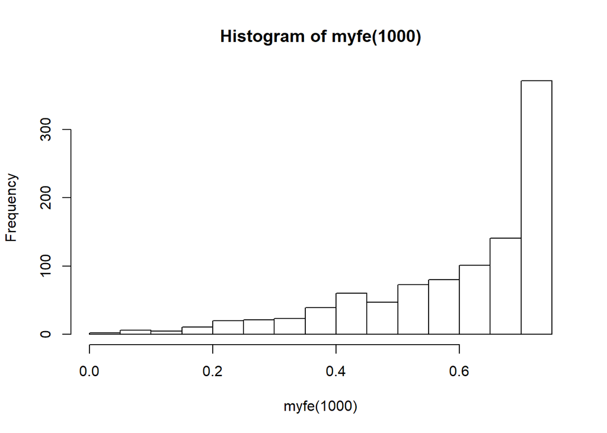

```r
myfe=function(n) {
  fe=numeric(n)
  for (i in 1:n){
  u1=runif(1,-1,1)
  u2=runif(1,-1,1)
  u3=runif(1,-1,1)
  if (abs(u3)>=abs(u2) & abs(u3)>=abs(u1)){
    u=u2
  }else {
    u=u3
  }
  fe[i]=3/4*(1-u^2)
  }
  return(fe)
}
hist(myfe(1000))
```